# Taller de Fundamentos Estadísticos para Finanzas Analíticas

Puntos I y II — Riesgo de mercado y optimización de portafolios

Autor/a

Esteban

Fecha de publicación

15 de agosto de 2026

# 1 Parámetros globales

**Ver código**

```r
ANIOS          <- 4          # ventana de análisis (últimos 4 años)
CONFIANZA      <- 0.95       # nivel de confianza para VaR/CVaR
INVERSION      <- 100000000  # exposición de USD 100.000.000
LAMBDA_EWMA    <- 0.94       # parámetro EWMA (Comité de Basilea)
DIAS_BOLSA     <- 252        # días bursátiles al año
SEMILLA        <- 1599
set.seed(SEMILLA)

fecha_final   <- Sys.Date()
fecha_inicial <- fecha_final %m-% years(ANIOS)
```

# 2 Punto II. Optimización de portafolios (4 acciones)

## 2.1 Selección y justificación de los activos

Se seleccionan cuatro acciones con perfomance parecidos en los ultimos años para ver como es su comportamiento al momento de conformar un poertafolio: https://finviz.com/screener?v=141&o=-perf3y

**Ver código**

```r
# ┌───────────────────────────────────────────────────────────────────────────┐
# │ CAMBIE AQUÍ LAS ACCIONES DEL PUNTO II. Edite la columna 'Ticker' con los   │
# │ símbolos de Yahoo Finance y actualice Empresa/Sector/Justificacion para    │
# │ que las tablas y el texto sean coherentes. Puede usar 3, 4, 5 o más        │
# │ acciones (agregue o quite filas). Ajuste PESO_MIN/PESO_MAX si cambia el    │
# │ número de activos: debe cumplirse  n_activos * PESO_MIN <= 1 <= n * PESO_MAX│
# └───────────────────────────────────────────────────────────────────────────┘
info_activos <- data.frame(
  Ticker  = c("MNPR", "AXTI", "DRUG", "TSSI"),
  Empresa = c("Monopar Therapeutics Inc", "AXTI Inc",
              "Bright Minds Biosciences Inc", "TSS Inc"),
  # Sector  = c("Tecnología / Software y nube", "Financiero / Banca",
  #             "Salud / Farmacéutica y consumo", "Energía / Petróleo y gas"),
  # Justificacion = c(
  #   "Líder global en software, nube (Azure) e IA; flujos de caja recurrentes y balance sólido.",
  #   "Banco universal diversificado; se beneficia del ciclo de tasas y del crédito.",
  #   "Salud defensiva; demanda inelástica, dividendos estables y baja sensibilidad al ciclo.",
  #   "Energética integrada; exposición al precio del crudo y cobertura frente a inflación."),
  stringsAsFactors = FALSE
)
knitr::kable(info_activos, caption = "Activos seleccionados y justificación fundamental")
```

| Ticker | Empresa |
| --- | --- |
| MNPR | Monopar Therapeutics Inc |
| AXTI | AXTI Inc |
| DRUG | Bright Minds Biosciences Inc |
| TSSI | TSS Inc |

**Ver código**

```r
tickers    <- info_activos$Ticker
n_activos  <- length(tickers)
PESO_MIN   <- 0.15    # ningún activo por debajo de 15%
PESO_MAX   <- 0.60    # ningún activo por encima de 60% (sin apalancamiento)
RF_ANUAL   <- 0.0425  # tasa libre de riesgo anual EA (T-Bill EE.UU. ~3M). Ajustable.
```

**Ver código**

```r
precios_II <- descargar_precios(tickers, fecha_inicial, fecha_final)
retornos_II <- na.omit(diff(log(precios_II)))
colnames(retornos_II) <- tickers

# Retornos anuales esperados (mu) y matriz de covarianzas anual (Sigma)
media_diaria <- apply(retornos_II, 2, mean)
vol_diaria   <- apply(retornos_II, 2, sd)
mu    <- anualizar_retorno(media_diaria, DIAS_BOLSA); names(mu) <- tickers
Sigma <- cov(coredata(retornos_II)) * DIAS_BOLSA
```

## 2.2 a) Multiplicadores de Lagrange y modelo de Markowitz

**Método de los multiplicadores de Lagrange.** Sirve para optimizar una función sujeta a restricciones de igualdad. Para minimizar $f(w)$ sujeto a $g(w)=0$ se define el lagrangiano $\mathcal{L}(w,\lambda)=f(w)-\lambda\,g(w)$ y se resuelve $\nabla_w \mathcal{L}=0$, $g(w)=0$. Cada multiplicador $\lambda$ mide la **sensibilidad del óptimo** ante una relajación marginal de su restricción (*precio sombra*).

**Aplicación al modelo media–varianza.** El problema de Markowitz de mínima varianza con retorno objetivo $R^\*$ es:

$$\min_{w}\; w'\Sigma w \quad \text{s.a.}\quad w'\mathbf{1}=1,\;\; w'\mu = R^\*.$$

Con lagrangiano $\mathcal{L}=w'\Sigma w-\lambda(w'\mathbf{1}-1)-\gamma(w'\mu-R^\*)$, las condiciones de primer orden dan la solución cerrada $w^\*=\Sigma^{-1}(\lambda\mathbf{1}+\gamma\mu)$, donde $\lambda,\gamma$ se despejan de las dos restricciones usando los escalares $A=\mathbf{1}'\Sigma^{-1}\mathbf{1}$, $B=\mathbf{1}'\Sigma^{-1}\mu$, $C=\mu'\Sigma^{-1}\mu$ y $D=AC-B^2$. La restricción $w'\mathbf{1}=1$ garantiza inversión total del capital y $w'\mu=R^\*$ fija el nivel de rentabilidad; recorrer $R^\*$ traza la **frontera eficiente**.

**Ver código**

```r
# Ejemplo resuelto: portafolio de mínima varianza global (solo suma = 1)
mvg <- markowitz_lagrange_analitico(mu, Sigma)
tab_mvg <- data.frame(Activo = tickers, Peso = mvg$w)
knitr::kable(tab_mvg, digits = 4,
  caption = "Ejemplo analítico (Lagrange): pesos de mínima varianza global sin cotas")
```

Ejemplo analítico (Lagrange): pesos de mínima varianza global sin cotas

| Activo | Peso |
| --- | --- |
| MNPR | 0.1686 |
| AXTI | 0.3926 |
| DRUG | 0.1365 |
| TSSI | 0.3023 |

**Ver código**

```r
# Ejemplo con retorno objetivo y multiplicadores explícitos
R_obj <- mean(mu)
sol   <- markowitz_lagrange_analitico(mu, Sigma, retorno_objetivo = R_obj)
cat(sprintf("Retorno objetivo R* = %.4f | lambda = %.5f | gamma = %.5f\n",
            R_obj, sol$lambda, sol$gamma))
```

```
Retorno objetivo R* = 0.9431 | lambda = 0.37380 | gamma = 0.16177
```

**Interpretación.** La solución analítica (sin cotas) reparte el capital priorizando los activos que más reducen la varianza conjunta. Los multiplicadores $\lambda$ y $\gamma$ son los precios sombra de las restricciones de presupuesto y de retorno objetivo: indican cuánto variaría la varianza mínima si se relajara marginalmente cada una. En los literales f–i se resuelve la versión **con cotas** ($15\%\le w_i\le 60\%$) mediante optimización numérica (SLSQP), que no admite fórmula cerrada por las desigualdades.

## 2.3 b) Rendimiento promedio efectivo anual de cada activo

**Ver código**

```r
tab_rend <- data.frame(Activo = tickers,
  Rendimiento_Anual_EA = as.numeric(mu))
knitr::kable(tab_rend, digits = 4, caption = "Rendimiento efectivo anual por activo")
```

Rendimiento efectivo anual por activo

| Activo | Rendimiento_Anual_EA |
| --- | --- |
| MNPR | 0.8755 |
| AXTI | 0.7118 |
| DRUG | 0.9856 |
| TSSI | 1.1997 |

**Ver código**

```r
act_mejor <- tickers[which.max(mu)]; act_peor <- tickers[which.min(mu)]
```

**Interpretación.** El activo de mayor rendimiento efectivo anual es **TSSI** (119.97%) y el de menor es **AXTI** (71.18%). Estas cifras reflejan el desempeño histórico de cada empresa en la ventana analizada y son el insumo de retorno esperado ($\mu$) para la optimización. Un rendimiento alto no es deseable por sí solo: debe evaluarse contra su riesgo (literal c) y su contribución al portafolio.

## 2.4 c) Volatilidad anualizada — activo más volátil

**Ver código**

```r
vol_anual <- anualizar_vol(vol_diaria, DIAS_BOLSA)
tab_vol <- data.frame(Activo = tickers, Volatilidad_Anual = as.numeric(vol_anual))
knitr::kable(tab_vol, digits = 4, caption = "Volatilidad anualizada por activo")
```

Volatilidad anualizada por activo

| Activo | Volatilidad_Anual |
| --- | --- |
| MNPR | 1.5630 |
| AXTI | 1.0671 |
| DRUG | 1.8557 |
| TSSI | 1.1556 |

**Ver código**

```r
act_volatil <- tickers[which.max(vol_anual)]
```

## 2.5 d) Correlaciones entre pares — diversificación

**Ver código**

```r
corr_II <- cor(coredata(retornos_II))
knitr::kable(corr_II, digits = 3, caption = "Matriz de correlaciones de retornos diarios")
```

Matriz de correlaciones de retornos diarios

|  | MNPR | AXTI | DRUG | TSSI |
| --- | --- | --- | --- | --- |
| MNPR | 1.000 | 0.052 | 0.030 | 0.120 |
| AXTI | 0.052 | 1.000 | 0.020 | 0.150 |
| DRUG | 0.030 | 0.020 | 1.000 | 0.035 |
| TSSI | 0.120 | 0.150 | 0.035 | 1.000 |

**Ver código**

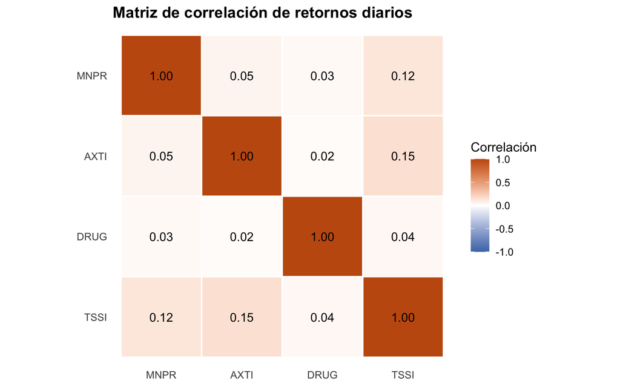

```r
corr_prom <- mean(corr_II[upper.tri(corr_II)])

# Versión gráfica (mapa de calor) de la matriz de correlaciones
print(g_corr_matriz(corr_II))
```

## 2.6 e) Portafolio equiponderado (25% cada activo)

**Ver código**

```r
w_eq <- rep(1 / n_activos, n_activos); names(w_eq) <- tickers
tab_eq <- resumen_port("Equiponderado", w_eq, mu, Sigma, RF_ANUAL, tickers)
knitr::kable(tab_eq, digits = 4, caption = "Portafolio equiponderado (25%)")
```

Portafolio equiponderado (25%)

| Portafolio | Peso_MNPR | Peso_AXTI | Peso_DRUG | Peso_TSSI | Rendimiento | Riesgo | Sharpe |
| --- | --- | --- | --- | --- | --- | --- | --- |
| Equiponderado | 0.25 | 0.25 | 0.25 | 0.25 | 0.9431 | 0.7804 | 1.1541 |

**Interpretación.** Repartir el capital en partes iguales produce un rendimiento anual esperado de 94.31% con un riesgo de 78.04%. Es una estrategia ingenua (no optimizada) pero útil como **referencia**: gracias a la diversificación, su riesgo ya es inferior al del activo más volátil visto en el literal c. Sirve de punto de comparación para juzgar el valor agregado de la optimización.

## 2.7 f) Portafolio de mínima varianza (15% ≤ wᵢ ≤ 60%)

**Ver código**

```r
w_mv <- opt_min_varianza(mu, Sigma, PESO_MIN, PESO_MAX, tickers)
tab_mv <- resumen_port("Mínima varianza", w_mv, mu, Sigma, RF_ANUAL, tickers)
knitr::kable(tab_mv, digits = 4, caption = "Portafolio de mínima varianza con restricciones")
```

Portafolio de mínima varianza con restricciones

| Portafolio | Peso_MNPR | Peso_AXTI | Peso_DRUG | Peso_TSSI | Rendimiento | Riesgo | Sharpe |
| --- | --- | --- | --- | --- | --- | --- | --- |
| Mínima varianza | 0.1658 | 0.3869 | 0.15 | 0.2974 | 0.9251 | 0.7239 | 1.2192 |

## 2.8 g) Portafolio de máximo rendimiento (15% ≤ wᵢ ≤ 60%)

**Ver código**

```r
w_mr <- opt_max_rendimiento(mu, Sigma, PESO_MIN, PESO_MAX, tickers)
tab_mr <- resumen_port("Máximo rendimiento", w_mr, mu, Sigma, RF_ANUAL, tickers)
knitr::kable(tab_mr, digits = 4, caption = "Portafolio de máximo rendimiento con restricciones")
```

Portafolio de máximo rendimiento con restricciones

| Portafolio | Peso_MNPR | Peso_AXTI | Peso_DRUG | Peso_TSSI | Rendimiento | Riesgo | Sharpe |
| --- | --- | --- | --- | --- | --- | --- | --- |
| Máximo rendimiento | 0.15 | 0.15 | 0.15 | 0.55 | 1.0458 | 0.8065 | 1.2439 |

## 2.9 h) 10.000 portafolios aleatorios factibles

**Ver código**

```r
sim_port <- simular_portafolios(mu, Sigma, RF_ANUAL, PESO_MIN, PESO_MAX,
                                n = 10000, semilla = SEMILLA)
cat("Portafolios simulados:", nrow(sim_port),
    "| Rendimiento medio:", pct(mean(sim_port$Rendimiento),2),
    "| Riesgo medio:", pct(mean(sim_port$Riesgo),2), "\n")
```

```
Portafolios simulados: 10000 | Rendimiento medio: 94.34% | Riesgo medio: 80.83%
```

**Ver código**

```r
knitr::kable(head(sim_port, 5), digits = 4,
  caption = "Muestra de portafolios aleatorios factibles")
```

Muestra de portafolios aleatorios factibles

| Rendimiento | Riesgo | Sharpe |
| --- | --- | --- |
| 0.9144 | 0.7303 | 1.1939 |
| 0.9536 | 0.7756 | 1.1746 |
| 0.8914 | 0.7808 | 1.0872 |
| 0.9048 | 0.7651 | 1.1270 |
| 0.9940 | 0.7888 | 1.2063 |

**Interpretación.** La simulación de 10.000 combinaciones de pesos que cumplen las restricciones genera la **nube de portafolios factibles** en el espacio riesgo–rendimiento. Su borde superior izquierdo aproxima la frontera eficiente: ningún portafolio puede situarse por encima y a la izquierda de ella.

## 2.10 i) Frontera eficiente y portafolios dominantes

**Ver código**

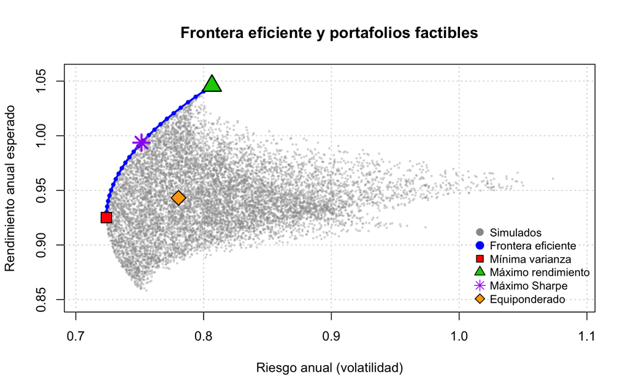

```r
fe <- frontera_eficiente(mu, Sigma, RF_ANUAL, PESO_MIN, PESO_MAX, tickers, n_puntos = 25)
w_ms <- opt_max_sharpe(mu, Sigma, RF_ANUAL, PESO_MIN, PESO_MAX, tickers)

# Límites con margen para que los extremos de la frontera no queden pegados al borde
xr <- range(c(sim_port$Riesgo, fe$Riesgo))
yr <- range(c(sim_port$Rendimiento, fe$Rendimiento))
xlim <- xr + c(-1, 1) * diff(xr) * 0.05
ylim <- yr + c(-1, 1) * diff(yr) * 0.06

plot(sim_port$Riesgo, sim_port$Rendimiento, pch = 16, cex = 0.4,
     col = rgb(0.6,0.6,0.6,0.4), xlim = xlim, ylim = ylim,
     xlab = "Riesgo anual (volatilidad)",
     ylab = "Rendimiento anual esperado",
     main = "Frontera eficiente y portafolios factibles")
grid()
# Frontera como línea con vértices pequeños (para no tapar los marcadores clave)
lines(fe$Riesgo, fe$Rendimiento, lwd = 2.5, col = "blue")
points(fe$Riesgo, fe$Rendimiento, pch = 19, cex = 0.6, col = "blue")

# Marcadores especiales con BORDE negro (símbolos 21-25), grandes y sin recorte.
# El de máximo rendimiento se dibuja de último (coincide con el extremo de la frontera).
points(riesgo_port(w_eq,Sigma), rend_port(w_eq,mu), pch = 23, cex = 2.0,
       bg = "orange", col = "black", lwd = 1.2, xpd = NA)
points(riesgo_port(w_ms,Sigma), rend_port(w_ms,mu), pch = 8,  cex = 2.0,
       col = "purple", lwd = 2.5, xpd = NA)
points(riesgo_port(w_mv,Sigma), rend_port(w_mv,mu), pch = 22, cex = 2.0,
       bg = "red", col = "black", lwd = 1.2, xpd = NA)
points(riesgo_port(w_mr,Sigma), rend_port(w_mr,mu), pch = 24, cex = 2.4,
       bg = "green3", col = "black", lwd = 1.5, xpd = NA)

legend("bottomright", bty = "n", cex = 0.85, pt.cex = 1.3,
  legend = c("Simulados","Frontera eficiente","Mínima varianza",
             "Máximo rendimiento","Máximo Sharpe","Equiponderado"),
  col = c("gray60","blue","black","black","purple","black"),
  pt.bg = c(NA, NA, "red", "green3", NA, "orange"),
  pch = c(16, 19, 22, 24, 8, 23))
```

**Ver código**

```r
# Coordenadas exactas de los portafolios clave (para ubicarlos en el gráfico)
cat(sprintf("Mínima varianza    -> Riesgo = %.4f | Rendimiento = %.4f\n",
            riesgo_port(w_mv,Sigma), rend_port(w_mv,mu)))
```

```
Mínima varianza    -> Riesgo = 0.7239 | Rendimiento = 0.9251
```

**Ver código**

```r
cat(sprintf("Máximo Sharpe      -> Riesgo = %.4f | Rendimiento = %.4f\n",
            riesgo_port(w_ms,Sigma), rend_port(w_ms,mu)))
```

```
Máximo Sharpe      -> Riesgo = 0.7514 | Rendimiento = 0.9936
```

**Ver código**

```r
cat(sprintf("Máximo rendimiento -> Riesgo = %.4f | Rendimiento = %.4f  (extremo sup. derecho)\n",
            riesgo_port(w_mr,Sigma), rend_port(w_mr,mu)))
```

```
Máximo rendimiento -> Riesgo = 0.8065 | Rendimiento = 1.0458  (extremo sup. derecho)
```

**Interpretación.** La frontera eficiente (azul) reúne los portafolios **dominantes**: para cada nivel de riesgo, el de máximo rendimiento (y viceversa). Cualquier portafolio por debajo de la curva está dominado —existe otro con igual riesgo y mayor retorno—. El portafolio equiponderado (naranja) se ubica en el interior de la nube, confirmando que la optimización agrega valor. Los puntos de mínima varianza (rojo) y máximo rendimiento (verde) marcan los **dos extremos** de la frontera: el de mínima varianza está en el vértice inferior izquierdo y el de máximo rendimiento coincide exactamente con el **extremo superior derecho** de la curva (por eso se dibuja sobre el último punto de la frontera). El de máximo Sharpe (púrpura) es el punto tangente, el óptimo riesgo-retorno.

## 2.11 j) Razón de Sharpe y recomendación

**Ver código**

```r
tab_ms <- resumen_port("Máximo Sharpe", w_ms, mu, Sigma, RF_ANUAL, tickers)
tab_h  <- data.frame(Portafolio = "Aleatorio (mejor Sharpe)",
  Rendimiento = sim_port$Rendimiento[which.max(sim_port$Sharpe)],
  Riesgo = sim_port$Riesgo[which.max(sim_port$Sharpe)],
  Sharpe = max(sim_port$Sharpe))

comparativo <- data.frame(
  Portafolio  = c("Equiponderado (e)","Mínima varianza (f)","Máximo rendimiento (g)",
                  "Mejor aleatorio (h)","Máximo Sharpe (i)"),
  Rendimiento = c(tab_eq$Rendimiento, tab_mv$Rendimiento, tab_mr$Rendimiento,
                  tab_h$Rendimiento, tab_ms$Rendimiento),
  Riesgo      = c(tab_eq$Riesgo, tab_mv$Riesgo, tab_mr$Riesgo,
                  tab_h$Riesgo, tab_ms$Riesgo),
  Sharpe      = c(tab_eq$Sharpe, tab_mv$Sharpe, tab_mr$Sharpe,
                  tab_h$Sharpe, tab_ms$Sharpe))
knitr::kable(comparativo, digits = 4,
  caption = paste0("Razón de Sharpe por portafolio (Rf = ", pct(RF_ANUAL,2), " EA)"))
```

Razón de Sharpe por portafolio (Rf = 4.25% EA)

| Portafolio | Rendimiento | Riesgo | Sharpe |
| --- | --- | --- | --- |
| Equiponderado (e) | 0.9431 | 0.7804 | 1.1541 |
| Mínima varianza (f) | 0.9251 | 0.7239 | 1.2192 |
| Máximo rendimiento (g) | 1.0458 | 0.8065 | 1.2439 |
| Mejor aleatorio (h) | 0.9887 | 0.7478 | 1.2654 |
| Máximo Sharpe (i) | 0.9936 | 0.7514 | 1.2658 |

**Ver código**

```r
recomendado <- comparativo$Portafolio[which.max(comparativo$Sharpe)]

# Pesos del portafolio de máximo Sharpe con las acciones seleccionadas
pesos_ms <- data.frame(Activo = tickers, Peso = as.numeric(w_ms))
knitr::kable(pesos_ms, digits = 4,
  caption = "Composición (pesos) del portafolio de máximo Sharpe")
```

Composición (pesos) del portafolio de máximo Sharpe

| Activo | Peso |
| --- | --- |
| MNPR | 0.1500 |
| AXTI | 0.2568 |
| DRUG | 0.1500 |
| TSSI | 0.4432 |

**Ver código**

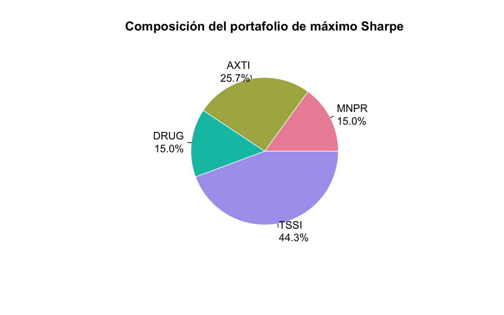

```r
# Diagrama circular (pie) de la composición
etiquetas_ms <- paste0(tickers, "\n", scales::percent(as.numeric(w_ms), accuracy = 0.1))
pie(as.numeric(w_ms),
    labels = etiquetas_ms,
    col = grDevices::hcl.colors(length(tickers), palette = "Set 2"),
    border = "white",
    main = "Composición del portafolio de máximo Sharpe")
```

**Interpretación.** Con una tasa libre de riesgo de **4.25% EA**, el portafolio recomendado desde la eficiencia riesgo-retorno es **Máximo Sharpe (i)**, por ofrecer la mayor rentabilidad excedente por unidad de riesgo (mayor Sharpe = 1.266). Su **composición** (tabla y gráfico de pesos) asigna la mayor ponderación a **TSSI** (44.3%) y la menor a **MNPR** (15.0%), siempre dentro de las cotas 15%–60%. El de mínima varianza es preferible para un perfil conservador y el de máximo rendimiento para uno agresivo, pero ninguno supera al de máximo Sharpe en eficiencia. La recomendación final depende del perfil del inversionista, aunque en términos de teoría de portafolios el punto tangente (máximo Sharpe) es el óptimo cuando se puede combinar con el activo libre de riesgo.

*Nota metodológica.* Todos los cálculos usan retornos logarítmicos diarios de los últimos 4 años. La tasa libre de riesgo (4.25% EA) es un supuesto ajustable en el bloque de parámetros del Punto II. Los códigos se encuentran en `funciones_taller.R` (funciones) y en este mismo documento.